# AI Adoption at the World Bank Group

Evidence from the AI-Enabled Research Bootcamp Baseline Survey

## Executive summary

- AI is already part of everyday work: 98% use it for their job and 68% of time-use respondents report at least one hour per day.
- Widespread use has not yet translated into broad adoption of advanced workflows: only 24% have tried a coding agent, 26% have created a memory file, and 27% have used someone else's reusable skill.
- AI is already helping respondents produce more and better work: 65% report producing more output, 66% higher-quality outputs, and 45% spending less time on analysis. These are self-reported benefits, not measured productivity gains.

These are self-reported baseline findings from bootcamp survey respondents, not measured impacts or a representative sample of WBG staff. Percentages use non-missing answers to each question; multi-select percentages need not sum to 100%. Tool use is ever-use for work; task use covers the last four weeks.

## Module 1: Current Use of Generative AI

- AI use is already widespread and intensive: 98% use it for work; among the 62 answering the time-use question, 68% report at least one hour per day.
- Chat and office tools dominate, while coding agents remain less common: among the 62 tool-question respondents, 100% have used mAI, 84% MS Copilot, and 81% third-party chat tools, compared with 24% who have used a coding agent.
- Writing and knowledge work lead recent use: Documents (85%), Background Research (82%), Email (69%) are the most common tasks; 48% also use AI for data analysis and visualization.
- AI-assisted work reaches outputs, but detailed disclosure is uncommon: 65% have had such work included in an output. Among those 40 answering the disclosure question, 28% gave detailed disclosure, 38% mentioned AI without details, and 28% wanted to disclose but were unsure how.

### 1.1 Current use of generative AI for work

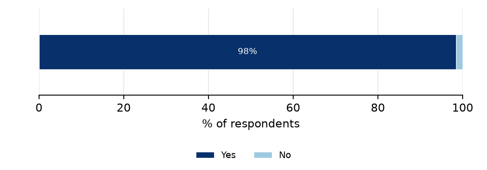

q1_1 · N = 63, Missing = 0

### 1.3 AI tools used for work

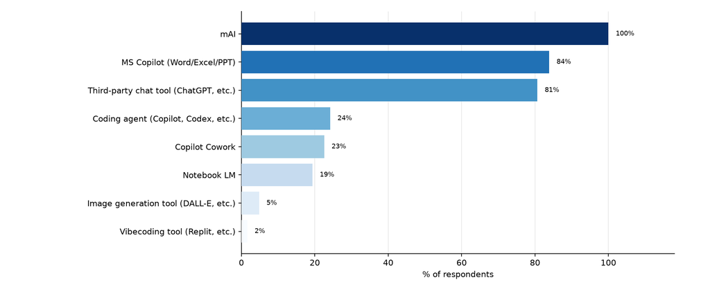

q1_3 · Select all that apply · N = 62

### 1.4 Time spent using GenAI per day

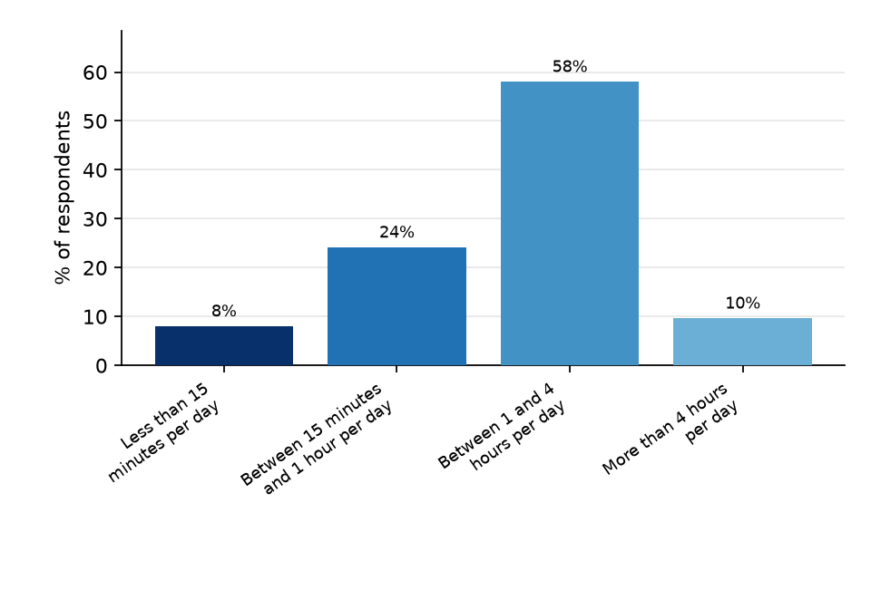

q1_4 · N = 62, Missing = 1

### 1.5 Tasks GenAI was used for

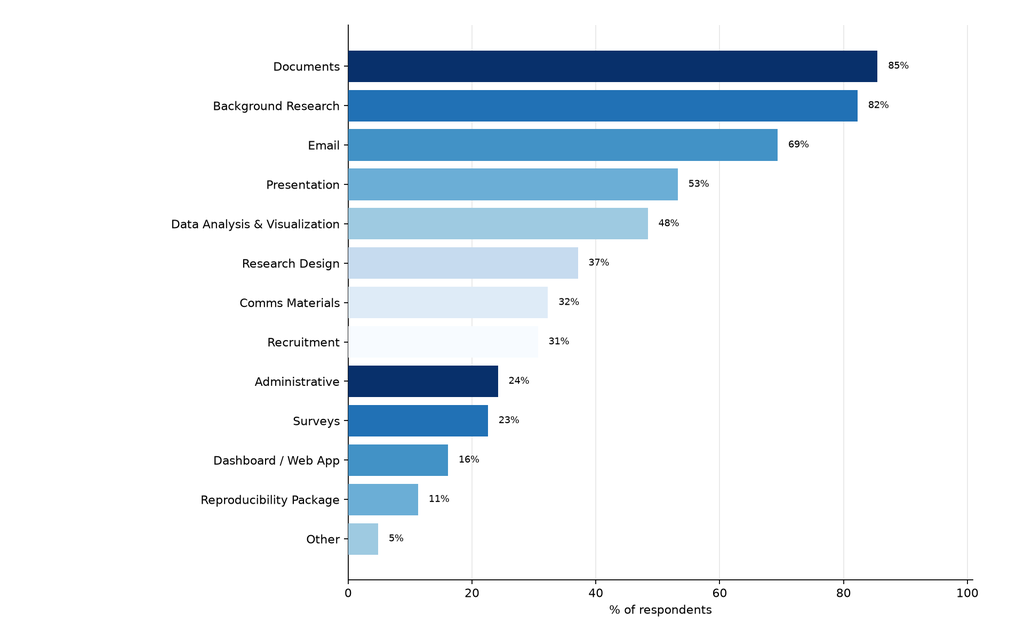

q1_5 · Select all that apply · N = 62

### 1.5 Usefulness of GenAI by task

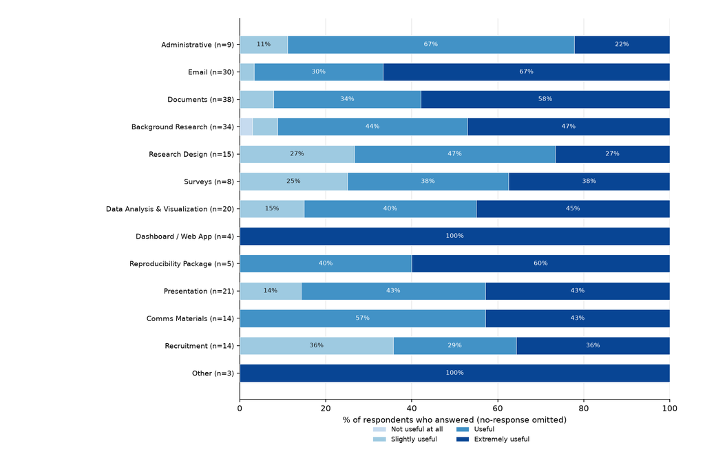

q1_5_use_* · Usefulness rating per item, no-response omitted

### 1.6 AI-assisted work included in outputs?

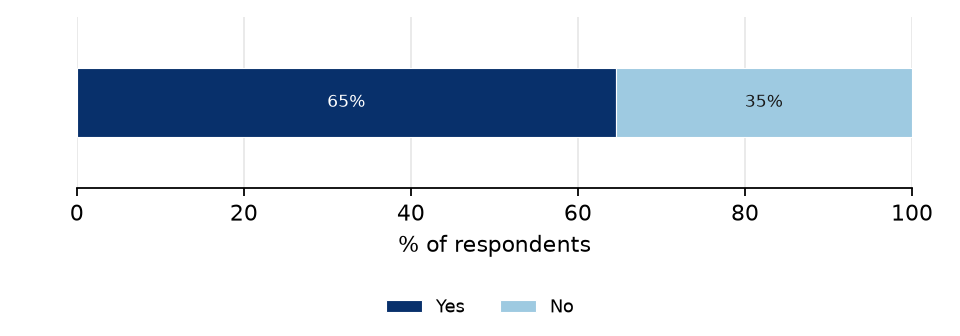

q1_6 · N = 62, Missing = 1

### 1.7 Was AI use disclosed?

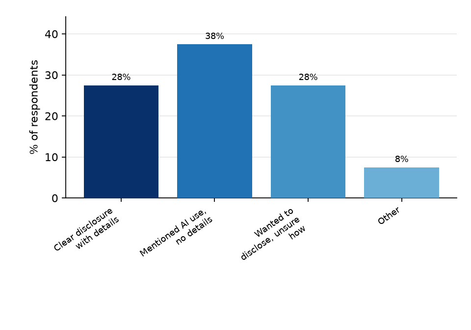

q1_7 · N = 40, Missing = 23

## Module 2: AI Workflows, Impact & Verification

- Memory files and reusable skills are not yet mainstream: 26% have created a memory file and 27% have used someone else's reusable skill; 50% and 37%, respectively, do not know what these are.
- Respondents report both quality and productivity benefits: 66% say AI helps them produce higher-quality outputs, 65% more output, and 47% more in-depth work. These are self-reported benefits, not measured impacts.
- Reproducibility gains are less evident: only 18% report improvement, while 45% report no change and 31% are unsure.
- Verification relies primarily on manual review: 77% manually review all outputs, compared with 34% using benchmarks and 23% using automated tests or QA checks.

### 2.1 Created an AI memory file?

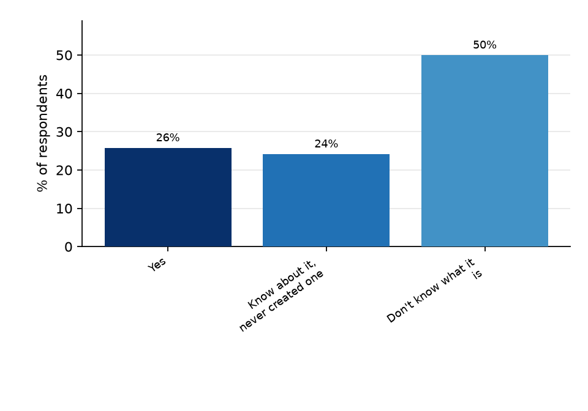

q2_1 · N = 62, Missing = 1

### 2.2 Used a reusable AI skill from someone else?

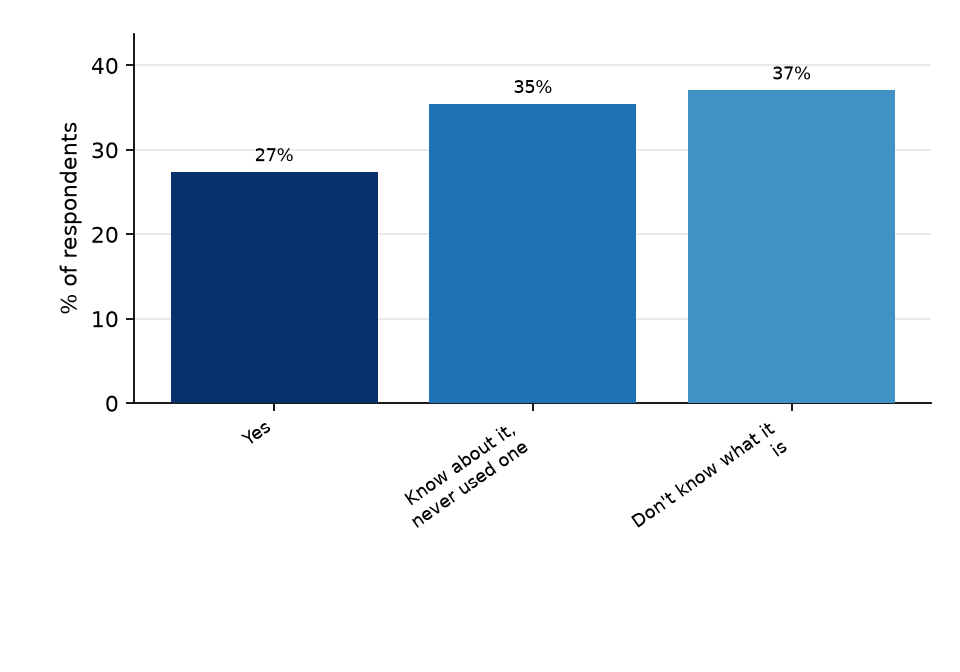

q2_2 · N = 62, Missing = 1

### 2.3 Effects of AI on analytical work

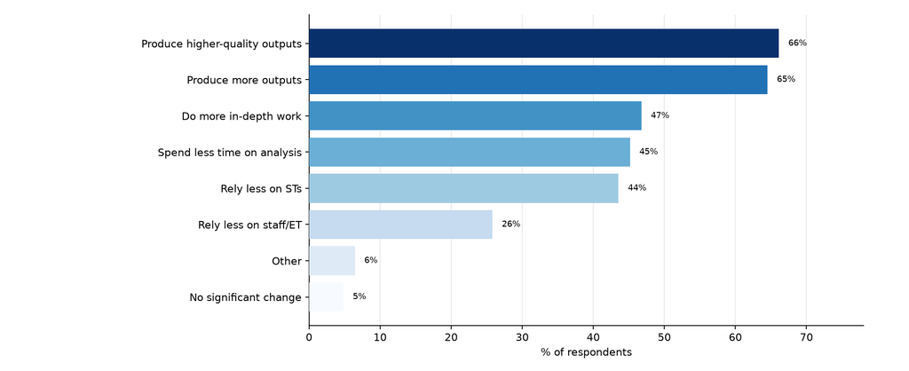

q2_3 · Select all that apply · N = 62

### 2.3.1 Extra output produced using AI

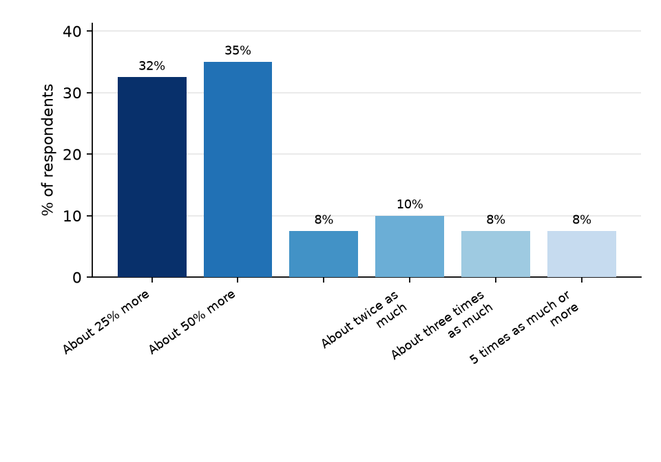

q2_3_1.1 · N = 40, Missing = 23

### 2.3.2 How AI improved work quality

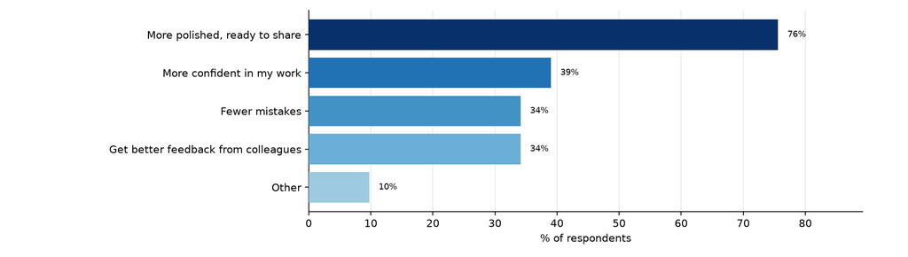

q2_3_2.1 · Select all that apply · N = 41

### 2.3.4 What would have happened without AI

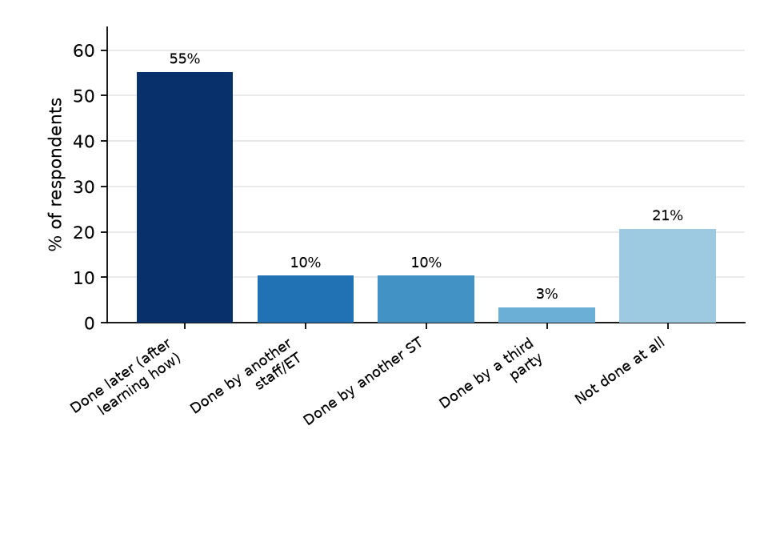

q2_3_4.1 · N = 29, Missing = 34

### 2.4 Effect of AI on reproducibility

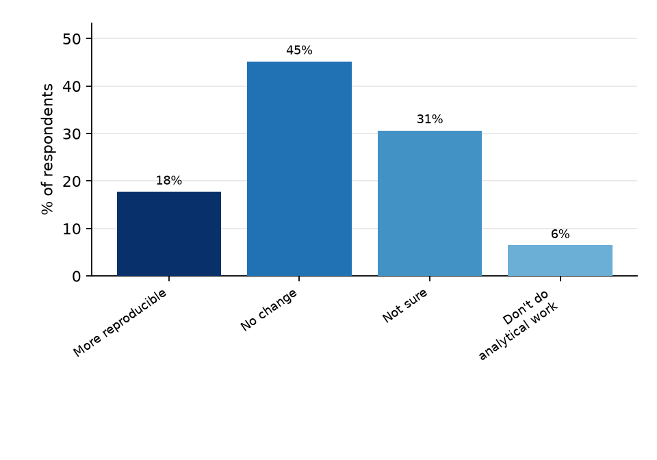

q2_4 · N = 62, Missing = 1

### 2.5 How AI output quality is verified

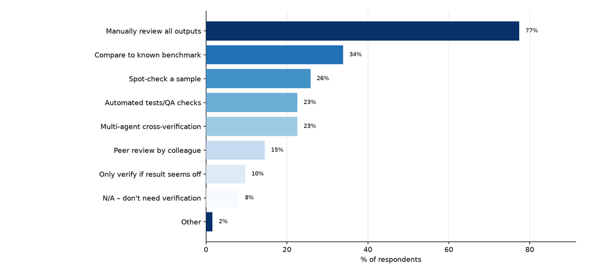

q2_5 · Select all that apply · N = 62

## Module 3: GitHub, Copilot & Safe AI Use

- GitHub-based workflows are not yet widely adopted: 22% currently use GitHub for version control, while 38% are unfamiliar with it.
- Active WBG Copilot use is limited: 10% are active users and another 13% have a license and are exploring; 69% have heard of it but never used it, or do not know what it is.
- Safe-use responses are split: 41% selected working with raw data in mAI/M365 Copilot, 41% selected synthetic-data-assisted script development with local execution, and 17% were unsure.

### 3.1 Use GitHub for version control?

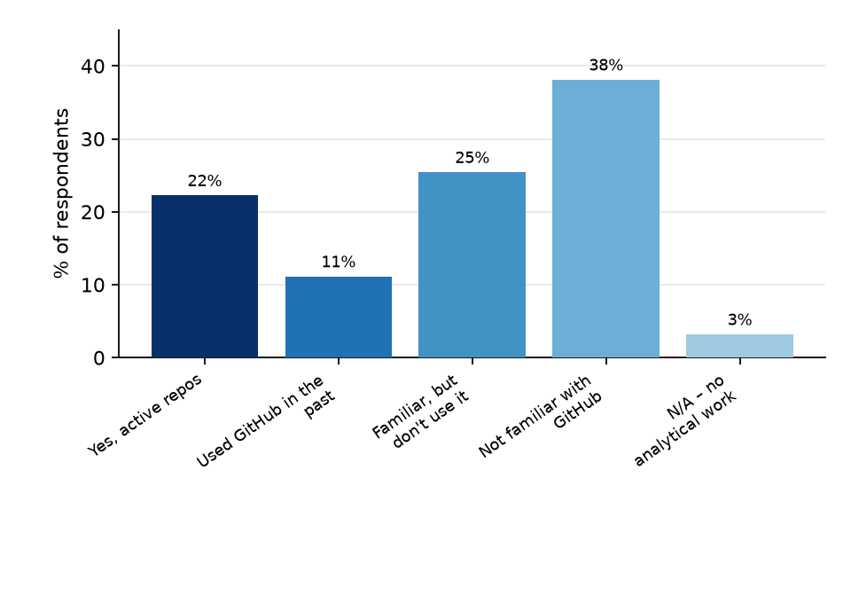

q3_1 · N = 63, Missing = 0

### 3.2 Use GitHub Copilot as a coding agent?

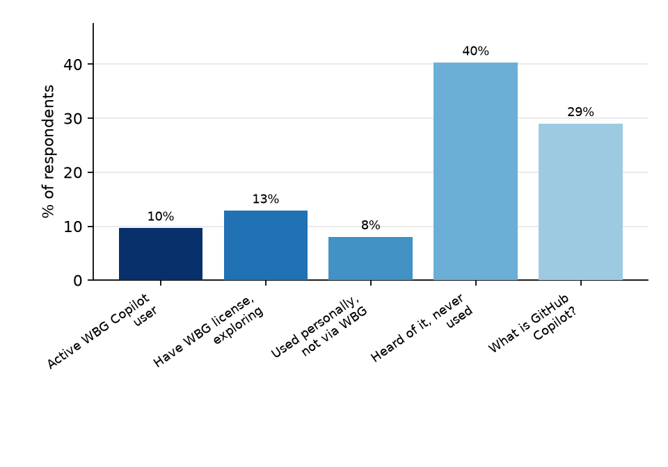

q3_2 · N = 62, Missing = 1

### 3.3 Safe-use knowledge check (confidential data + AI)

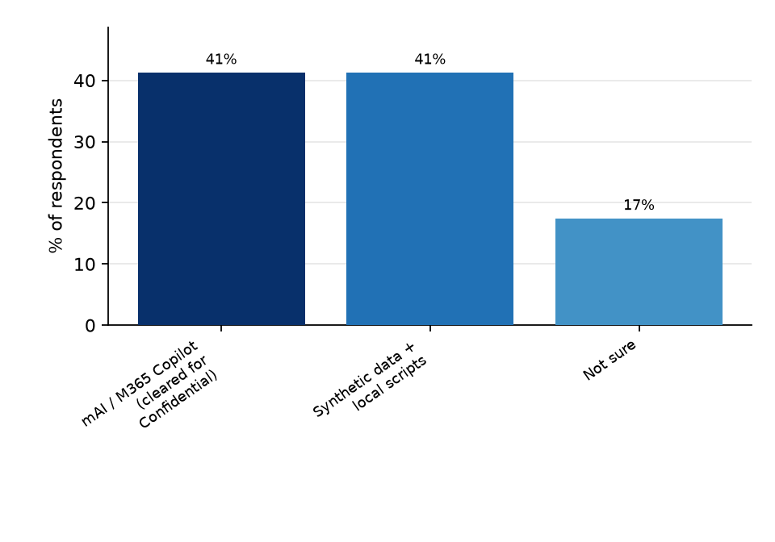

q3_3 · N = 63, Missing = 0

## Module 4: Background & Expectations

- Participants bring substantial WBG experience: 67% have worked at the WBG for 5–19 years.
- Expectations are strongly practical: 94% want tools they can apply to their jobs and 86% greater productivity; improving work quality (79%) and technical skills (79%) are also priorities.
- Extensive AI use coexists with limited formal preparation and self-rated expertise: 75% have not taken an AI-for-research course; 40% rate their knowledge poor/very poor, 46% average, and only 14% good/excellent.

### 4.2 Years at the World Bank

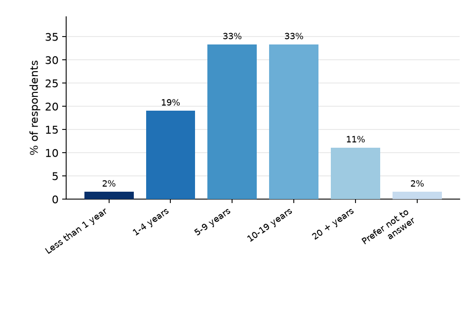

q4_2 · N = 63, Missing = 0

### 4.3 What attendees want from the Bootcamp

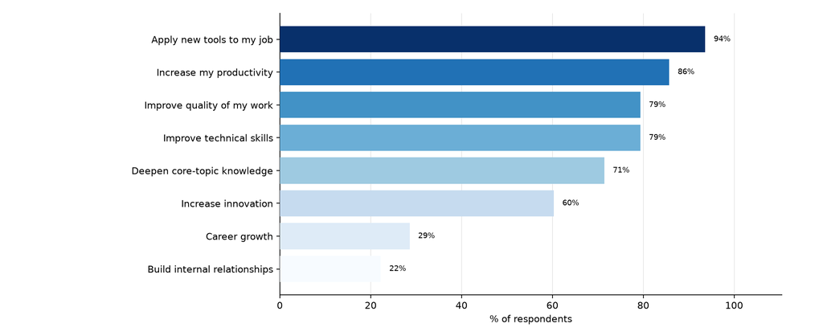

q4_3 · Select all that apply · N = 63

### 4.4 Taken an AI-for-research course before?

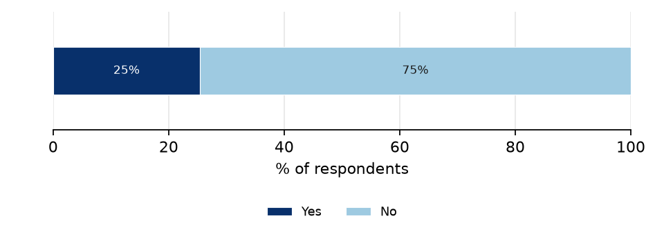

q4_4 · N = 63, Missing = 0

### 4.5 Self-rated AI-for-research knowledge

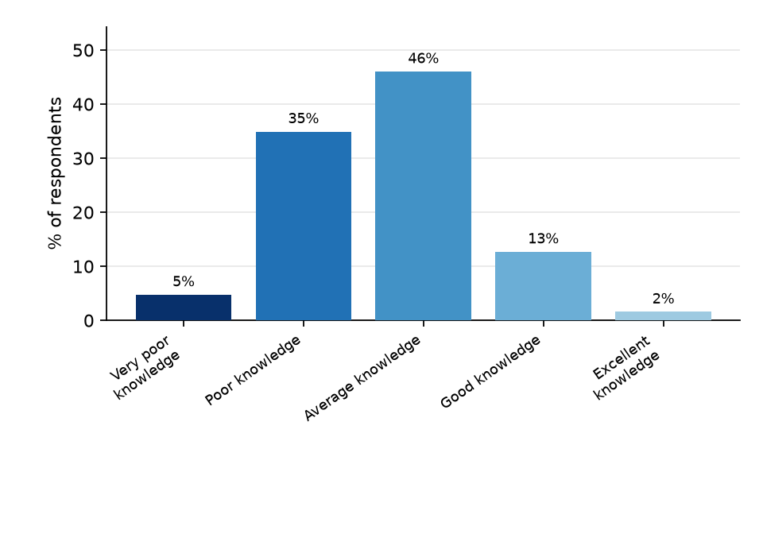

q4_5 · N = 63, Missing = 0